# HW 10

Nicholas Alexeev

11/14/2021

# 1. 1 (a,d) Consider a normal population distribution with the vaue of stdev known

## a. What is confidence level for the interval x +- 2.74 stdev/sqrt(n)

99.4%

## b. What valye of z_(a/2) in the CI formula (7.5) results in a confidence level of 82%?

1.34

# 2. Each of the following is a confidence interval for mean= rue average (i.e., populationmean) resonance frequency (Hz) for all tennis rackets of a certain type:

Type A: (114.4, 115.6) Type B: (114.1, 115.9)

## a. What is the value of the sample mean resonance frequency for each type?

Type A: (114.4+115.6)/2 = 115.0

Type B: (114.1 + 115.9)/2 = 115.0

## b. Both intervals were calculated from the same sample data. The confidence level forone of these intervals is 90% and the other is 99%. Which of the intervals has the 90%confidence level, and why? [Hint: The 99% CI is wider than the 90% CI, but why? Theanswer doesn’t have anything to do with the formula. It has to do with what happens99% of the time versus 90% of the time.]

# 3. modified. Assume that the helium porosity (in percentage) of coal samplestaken from any particular seam is normally distributed with true standard deviation 0.75.

## a. Compute a 95% CI for the true average porosity of a certain seam if the average porosity for 20 specimens from the seam was 4.85.

$$\left(4.85-1.96*\frac{0.75}{\sqrt{20}},4.85+1.96*\frac{0.75}{\sqrt{20}}\right) = \left(4.85-0.33,4.85+0.33\right) = (4.52,5.18)$$

## b. Provide an informal interpretation of the CI in (a).

There is a 95% chance that the true mean lies inside of the interval (4.52,5.18).

## c. Provide a formal interpretation of the CI in (a).

If the experiment is repeated, there is a 95% chance that the measured sample mean will line in the interval (4.52,5.18).

## d. What sample size is necessary to estimate true average porosity to within 0.2 with 99% confidence?

$$n = 94$$

# 4. 7.2 # 18 (modified) The U.S. Army commissioned a study to assess how deeply abullet penetrates ceramic body armor. (Reference cited in text.) In the standard test,a cylindrical clay model is layered under the armor vest. A projectile is then fired,causing an indentation in the clay. The deepest impression in the clay is measured asan indication of survivability of someone wearing the armor. The data for the problemappears in the text; I’ve also posted a file with the data and also R code for this problem.The measurements are in mm.

## a. Construct a boxplot and a histogram of the data and comment on features. Be sureto include the plots in your solutions

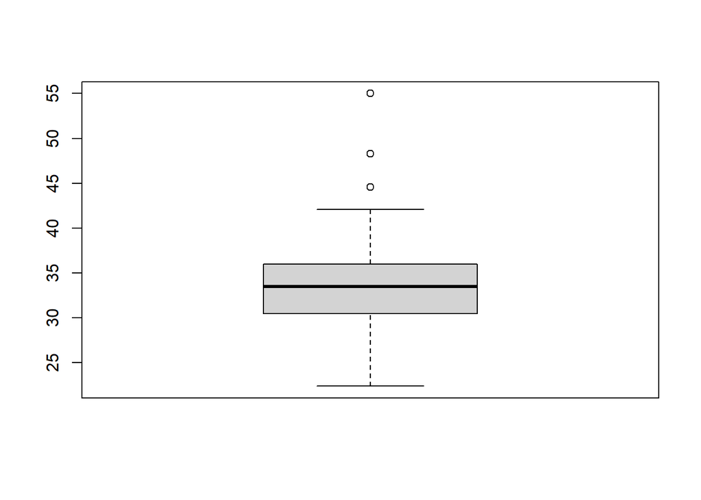

```r
Depth <- c(
22.4,23.6,24.0,24.9,25.5,25.6,
25.8,26.1,26.4,26.7,27.4,27.6,
28.3,29.0,29.1,29.6,29.7,29.8,
29.9,30.0,30.4,30.5,30.7,30.7,
31.0,31.0,31.4,31.6,31.7,31.9,
31.9,32.0,32.1,32.4,32.5,32.5,
32.6,32.9,33.1,33.3,33.5,33.5,
33.5,33.5,33.6,33.6,33.8,33.9,
34.1,34.2,34.6,34.6,35.0,35.2,
35.2,35.4,35.4,35.4,35.5,35.7,
35.8,36.0,36.0,36.0,36.1,36.1,
36.2,36.4,36.6,37.0,37.4,37.5,
37.5,38.0,38.7,38.8,39.8,41.0,
42.0,42.1,44.6,48.3,55.0)
boxplot(Depth)
```

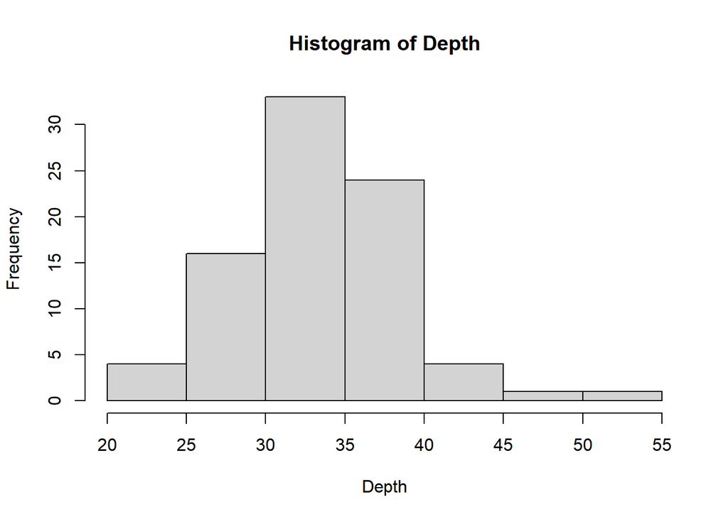

```r
hist(Depth)
```

The plots resemble a normal distribution except the depth is skewed to the right.

## b. Construct a normal probability plot, and include it with your solutions. (Again,the R code is in the attached file.) Is it plausible that impression depth is normally distributed? Is a normal distribution assumption needed in order to calculate a CI orbound for the true average depth using the included data? Explain

```r
library(car)
```

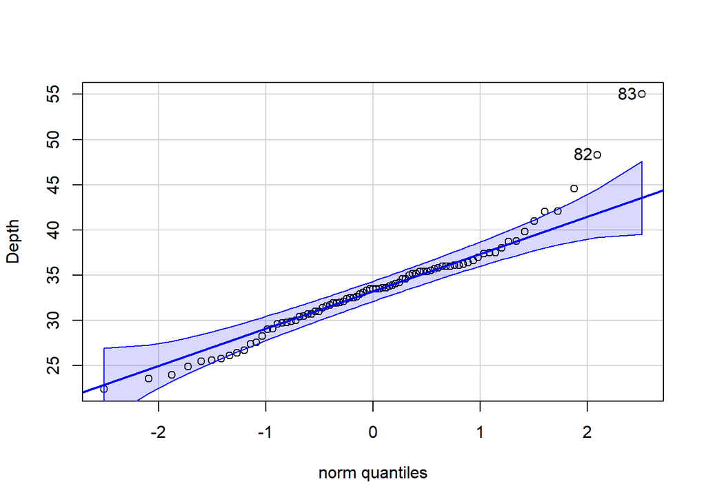

```
## [1] 83 82
```

```r
qqPlot(Depth)
```

It is not reasonable to assume that the data is normally distributed as the high values do not follow a normnal distribution.

## c. Theinterpretation of this type of interval is this: We are 99% confident that the true average impression depth lies below ____.

```r
length(Depth)
```

```
## [1] 83
```

```r
qt(0.995,83)
```

```
## [1] 2.636369
```

```r
mean(Depth)+qt(0.995,83) *sd(Depth)/sqrt(length(Depth))
```

```
## [1] 34.89442
```

```r
t.test(Depth,conf.level=0.98)
```

```
##
##  One Sample t-test
##
## data:  Depth
## t = 57.706, df = 82, p-value < 2.2e-16
## alternative hypothesis: true mean is not equal to 0
## 98 percent confidence interval:
##  31.99782 34.74194
## sample estimates:
## mean of x
##  33.36988
```

# 5. In a Quinnipiac (KWIN-uh-pea-ack) University poll in late September, 2021, a sample ofapproximately 1000 registered Texas voters were asked whether abortion should be legalin cases of rape or incest. Of these, approximately 77% said Yes; 16% said No, and 7%had other responses. Using these figures as if they are exact (770 out of 1000 said Yes),construct a 95% confidence interval for the true proportion of all Texas registered voterswho would answer Yes to this question. Interpret your CI. (Use the better of the twoformulas discussed in class, on page 168 of the lecture notes.)

$$\sigma = \sqrt{\frac{p(1-p)}{n}} = \sqrt{\frac{0.77*0.23}{1000}} = 0.013$$
$$(0.77-1.96*0.013,0.77+1.96*0.013) = (0.744,0.796)$$

# 6. Determine the values of the following quantities; use both R (the function qt) and TableA.5.

## a. t_0.1,df=15

1.341

```r
qt(1-0.1,15)
```

```
## [1] 1.340606
```

## b. t_0.05 df = 31

1.695

```r
qt(1-0.05,31)
```

```
## [1] 1.695519
```

```r
qt(1-0.025,31)
```

```
## [1] 2.039513
```

# 7. Find the t critical value for a two-sided confidence interval in each of the following situations; use R and also Table A.5.

## a. df = 10, 95% COnfidence level.

2.228

```r
qt(0.95+0.025,10)
```

```
## [1] 2.228139
```

## b. df = 15. 90% confidence level.

1.753

```r
qt(0.95,15)
```

```
## [1] 1.75305
```

## c. df = 45, 99% confidence level.

2.691

```r
qt(0.995,45)
```

```
## [1] 2.689585
```

# 8. Use the cadence data from problem # 37 in 7.3 to form a 95% confidence interval for theaverage cadence using the bootstrap method. Compare this with the interval we foundin class (page 172 of the lecture notes). R code for the bootstrap procedure appears onpage 165 of the lecture notes.

```r
data <- c(0.95,0.85,0.92,0.95,0.93,0.86,1.0,0.92,0.85,0.81,0.78,0.93,0.93,1.05,0.93,1.06,0.96,0.81,0.96)
n <- length(data)
b <- 5000
results <- rep(NA,b)
for(i in 1:b){
  my.sample <- sample(data,size = n, replace = TRUE)
  results[i]<-mean(my.sample)
}
length(unique(results))
```

```
## [1] 238
```

```r
lower.lim <- quantile(results,0.025)
upper.lim <- quantile(results,0.975)
c(lower.lim,upper.lim)
```

```
##      2.5%     97.5%
## 0.8842105 0.9505263
```

The interval found in class was wider then the interval that I found.

# 9. In an FBI study on propery crimes, a sample of 25 pickpocket offenses was analyzed.The data (amount stolen) appear to come from a normal population. The mean amountstolen was$513.32 and the sample standard deviation was$262.23. Find and interpret a 95% confidence interval for the average amount stolen by pickpockets

$$\left(513.32-2.064*\frac{262.23}{\sqrt{25}},513.32+2.064*\frac{262.23}{\sqrt{25}}\right) = (513.32-108,513.32+108) = (404.98,621.47)$$

# 10. For the following pairs of hypotheses, indicate whether each does or does not comply with our rules for setting up hypotheses. If a pair doesn’t comply with the rules, be sure to say why not.

## a. H0, u = 50, Ha u <50

Yes

## b. H0 p != 0.6 vs Ha p=0.6

invalid, H0 must be an equality

## c. H0 p_hat = 0.5 vs Ha p_hat != 0.5

No as p_hat describes a sample rather then the population

## d. H0 u = 5.1 vs Ha u > 5.4

invalid there is a gap between H0 and Ha.

## e. H0 x_bar = 16.0 vs Ha x_bar != 16.0

No as x_bar describes a sample rather then the population

## f. H0 u1 -u2 = 10.0 vs Ha u1-u2 !=10.0

yes